# Assignment 9: Spatial Analysis in R

Asreeta Ushasri

## OVERVIEW

This exercise accompanies the lessons in Environmental Data Analytics (ENV872L) on spatial analysis.

## Directions

1. Rename this file `<FirstLast>_A09_SpatialAnalysis.Rmd` (replacing `<FirstLast>` with your first and last name).
2. Change “Student Name” on line 3 (above) with your name.
3. Use the lesson as a guide. It contains code that can be modified to complete the assignment.
4. Work through the steps, **creating code and output** that fulfill each instruction.
5. Be sure to **answer the questions** in this assignment document. Space for your answers is provided in this document and is indicated by the “>” character. If you need a second paragraph be sure to start the first line with “>”. You should notice that the answer is highlighted in green by RStudio.
6. When you have completed the assignment, **Knit** the text and code into a single **HTML** file.

## DATA WRANGLING

### Set up your session

1. Import libraries: tidyverse, sf, leaflet, here, and mapview
2. Execute the `here()` command to display the current project directory

```r
#1. Import libraries

library(tidyverse)
library(lubridate)
library(here)
library(dplyr)

#install.packages('sf')
library(sf)
```

```r
#install.packages('leaflet')
library(leaflet)
#install.packages('mapview')
library(mapview); mapviewOptions(fgb = FALSE)

#Disable on-the-fly projections
sf::sf_use_s2(FALSE)
```

```
## Spherical geometry (s2) switched off
```

```r
#2. Display current project directory
here()
```

```
## [1] "/home/guest/AU_EDE_Fall2024"
```

### Read (and filter) county features into an sf dataframe and plot

In this exercise, we will be exploring stream gage height data in Nebraska corresponding to floods occurring there in 2019. First, we will import from the US Counties shapefile we’ve used in lab lessons, filtering it this time for just Nebraska counties. Nebraska’s state FIPS code is `31` (as North Carolina’s was `37`).

3. Read the `cb_2018_us_county_20m.shp` shapefile into an sf dataframe, filtering records for Nebraska counties (State FIPS = 31)
4. Reveal the dataset’s coordinate reference system
5. Plot the records as a map (using `mapview` or `ggplot`)

```r
#3. Read in Counties shapefile into an sf dataframe

NE_Counties <- st_read(here('Data/Raw/Spatial/cb_2018_us_county_20m.shp'))
#view(NE_Counties)

#Filter for just NE counties

NE_Counties <- NE_Counties %>%
  filter(STATEFP == 31)

#4. Reveal the CRS of the counties features

st_crs(NE_Counties)
```

```
## Coordinate Reference System:
##   User input: NAD83
##   wkt:
## GEOGCRS["NAD83",
##     DATUM["North American Datum 1983",
##         ELLIPSOID["GRS 1980",6378137,298.257222101,
##             LENGTHUNIT["metre",1]]],
##     PRIMEM["Greenwich",0,
##         ANGLEUNIT["degree",0.0174532925199433]],
##     CS[ellipsoidal,2],
##         AXIS["latitude",north,
##             ORDER[1],
##             ANGLEUNIT["degree",0.0174532925199433]],
##         AXIS["longitude",east,
##             ORDER[2],
##             ANGLEUNIT["degree",0.0174532925199433]],
##     ID["EPSG",4269]]
```

```r
#5. Plot the data

mapview(NE_Counties, zcol='NAME', legend = TRUE,
        layer.name = "Nebraska Counties")
```

[interactive chart not shown]

6. What is the EPSG code of the Counties dataset? Is this a geographic or a projected coordinate reference system? (Om other words, does this CRS use angular or planar coordinate units?) To what datum is this CRS associated? (Tip: look for the EPSG code on https://epsg.io)

> ANSWER: The EPSD code of this dataset is 4269. This represents the NAD83 or the North American Datum 1983. This is a Geographic Coordinate Reference System (NOAA, 2018).

### Read in gage locations csv as a dataframe, then display the column names it contains

Next we’ll read in some USGS/NWIS gage location data added to the `Data/Raw` folder. These are in the `NWIS_SiteInfo_NE_RAW.csv` file.(See `NWIS_SiteInfo_NE_RAW.README.txt` for more info on this dataset.)

7. Read the `NWIS_SiteInfo_NE_RAW.csv` file into a standard dataframe, being sure to set the `site_no` field as well as other character columns as a factor.
8. Display the structure of this dataset.

```r
#7. Read in gage locations csv as a dataframe

Gage_Locations_DF <- read.csv(here("Data/Raw/NWIS_SiteInfo_NE_RAW.csv"),
                           stringsAsFactors=TRUE)

#8. Display the structure of the dataframe

#view(Gage_Locations_DF)
head(Gage_Locations_DF)
```

```
##   site_no                            station_nm site_tp_cd dec_lat_va
## 1 6453600          Ponca Creek at Verdel, Nebr.         ST   42.81111
## 2 6454100        Niobrara River at Agate, Nebr.         ST   42.42361
## 3 6461500     Niobrara River near Sparks, Nebr.         ST   42.90222
## 4 6463500 Long Pine Creek near Riverview, Nebr.         ST   42.68944
## 5 6463720   Niobrara River at Mariaville, Nebr.         ST   42.78056
## 6 6465500     Niobrara River near Verdel, Nebr.         ST   42.73972
##   dec_long_va coord_acy_cd dec_coord_datum_cd
## 1   -98.17583            S              NAD83
## 2  -103.79222            S              NAD83
## 3  -100.36222            S              NAD83
## 4   -99.67889            S              NAD83
## 5   -99.33972            S              NAD83
## 6   -98.22278            S              NAD83
```

```r
str(Gage_Locations_DF)
```

```
## 'data.frame':    175 obs. of  7 variables:
##  $ site_no           : int  6453600 6454100 6461500 6463500 6463720 6465500 6465700 6466400 6466500 6478518 ...
##  $ station_nm        : Factor w/ 175 levels " BIG SANDY CR AT ALEXANDRIA, NE",..: 117 85 87 70 86 88 162 7 8 24 ...
##  $ site_tp_cd        : Factor w/ 1 level "ST": 1 1 1 1 1 1 1 1 1 1 ...
##  $ dec_lat_va        : num  42.8 42.4 42.9 42.7 42.8 ...
##  $ dec_long_va       : num  -98.2 -103.8 -100.4 -99.7 -99.3 ...
##  $ coord_acy_cd      : Factor w/ 6 levels "1","5","F","H",..: 6 6 6 6 6 6 6 6 6 6 ...
##  $ dec_coord_datum_cd: Factor w/ 1 level "NAD83": 1 1 1 1 1 1 1 1 1 1 ...
```

9. What columns in the dataset contain the x and y coordinate values, respectively?

> ANSWER: The dec_long_va depicts the longitude of the locations, which would correspond with the x value. The dec_lat_va column contains the latitude of the locations. On a 2D display, the latitude would correspond with an y value.

### Convert the dataframe to a spatial features (“sf”) dataframe

10. Convert the dataframe to an sf dataframe. * Note: These data use the same coordinate reference system as the counties dataset
11. Display the structure of the resulting sf dataframe

```r
#10. Convert to an sf object

Gage_Locations_SF <- Gage_Locations_DF %>%
  st_as_sf(
    coords = c('dec_long_va','dec_lat_va'),
    crs=4269
    )

#11. Display the structure

#view(Gage_Locations_SF)
head(Gage_Locations_SF)
```

```
## Simple feature collection with 6 features and 5 fields
## Geometry type: POINT
## Dimension:     XY
## Bounding box:  xmin: -103.7922 ymin: 42.42361 xmax: -98.17583 ymax: 42.90222
## Geodetic CRS:  NAD83
##   site_no                            station_nm site_tp_cd coord_acy_cd
## 1 6453600          Ponca Creek at Verdel, Nebr.         ST            S
## 2 6454100        Niobrara River at Agate, Nebr.         ST            S
## 3 6461500     Niobrara River near Sparks, Nebr.         ST            S
## 4 6463500 Long Pine Creek near Riverview, Nebr.         ST            S
## 5 6463720   Niobrara River at Mariaville, Nebr.         ST            S
## 6 6465500     Niobrara River near Verdel, Nebr.         ST            S
##   dec_coord_datum_cd                   geometry
## 1              NAD83 POINT (-98.17583 42.81111)
## 2              NAD83 POINT (-103.7922 42.42361)
## 3              NAD83 POINT (-100.3622 42.90222)
## 4              NAD83 POINT (-99.67889 42.68944)
## 5              NAD83 POINT (-99.33972 42.78056)
## 6              NAD83 POINT (-98.22278 42.73972)
```

```r
str(Gage_Locations_SF)
```

```
## Classes 'sf' and 'data.frame':   175 obs. of  6 variables:
##  $ site_no           : int  6453600 6454100 6461500 6463500 6463720 6465500 6465700 6466400 6466500 6478518 ...
##  $ station_nm        : Factor w/ 175 levels " BIG SANDY CR AT ALEXANDRIA, NE",..: 117 85 87 70 86 88 162 7 8 24 ...
##  $ site_tp_cd        : Factor w/ 1 level "ST": 1 1 1 1 1 1 1 1 1 1 ...
##  $ coord_acy_cd      : Factor w/ 6 levels "1","5","F","H",..: 6 6 6 6 6 6 6 6 6 6 ...
##  $ dec_coord_datum_cd: Factor w/ 1 level "NAD83": 1 1 1 1 1 1 1 1 1 1 ...
##  $ geometry          :sfc_POINT of length 175; first list element:  'XY' num  -98.2 42.8
##  - attr(*, "sf_column")= chr "geometry"
##  - attr(*, "agr")= Factor w/ 3 levels "constant","aggregate",..: NA NA NA NA NA
##   ..- attr(*, "names")= chr [1:5] "site_no" "station_nm" "site_tp_cd" "coord_acy_cd" ...
```

12. What new field(s) appear in the sf dataframe created? What field(s), if any, disappeared?

> ANSWER: Geometry is a new column in the SF dataframe. The geometry column provides details on the spatial data points. Meanwhile, the dec_long_va and dec_lat_vacolumns disappeared in the SF dataframe. These represent the x and y coordinates of the new spatial points created in the SF dataframe, and therefore are incoporated in the geometry field.

### Plot the gage locations on top of the counties

13. Use `ggplot` to plot the county and gage location datasets.
- Be sure the datasets are displayed in different colors
- Title your plot “NWIS Gage Locations in Nebraska”
- Subtitle your plot with your name

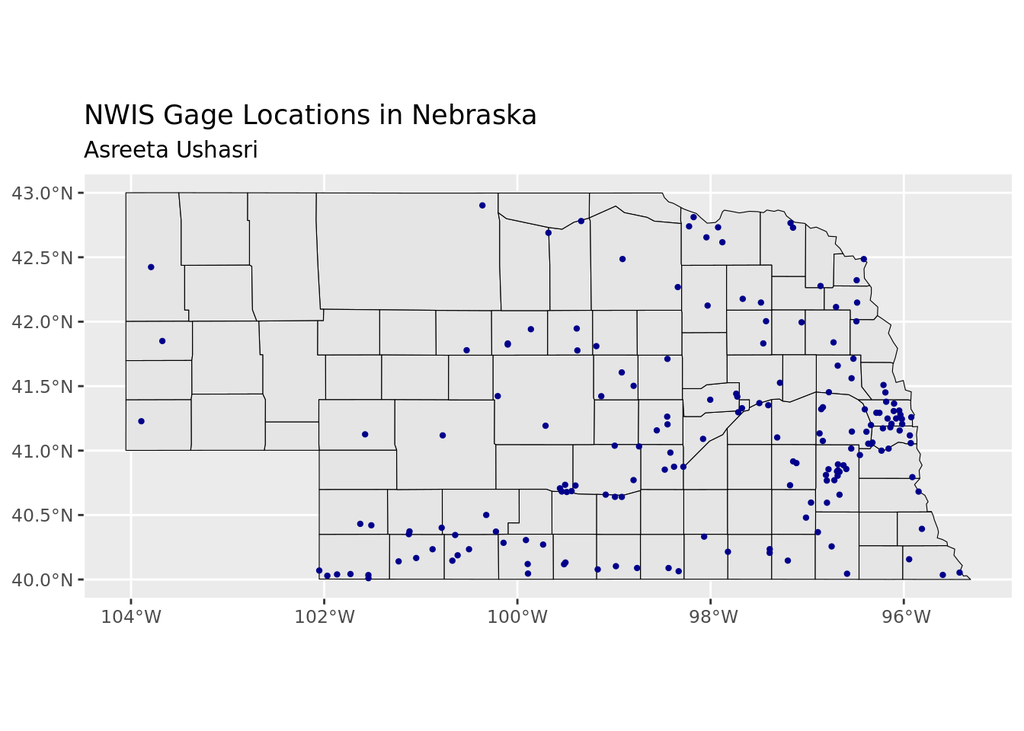

```r
#13. Plot the gage locations atop the county features

ggplot() +
  geom_sf(data = NE_Counties, color = 'black') +
  geom_sf(data = Gage_Locations_SF, color = 'darkblue', size = 0.8) + theme(
    panel.background = element_rect(color = "white"),
    legend.key = element_rect(color = "white")) +
  labs(title = "NWIS Gage Locations in Nebraska",
       subtitle = "Asreeta Ushasri")
```

### Read in the gage height data and join the site location data to it.

Lastly, we want to attach some gage height data to our site locations. I’ve constructed a csv file listing many of the Nebraska gage sites, by station name and site number along with stream gage heights (in meters) recorded during the recent flood event. This file is titled `NWIS_SiteFlowData_NE_RAW.csv` and is found in the Data/Raw folder.

14. Read the `NWIS_SiteFlowData_NE_RAW.csv` dataset in as a dataframe
    - Pay attention to which fields should be imported as factors!
15. Show the column names.
16. Join our site information (already imported above) to these gage height data
    - The `site_no` and `station_nm` can both/either serve as joining attributes
    - Construct this join so that the result only includes records features where both tables have data (N=136)
17. Show the column names of this resulting spatial dataframe
18. Show the dimensions of the resulting joined dataframe

```r
#14. Read the site flow data into a data frame

Site_Flow_DF <- read.csv(here("Data/Raw/NWIS_SiteFlowData_NE_RAW.csv"),
                           stringsAsFactors=TRUE)


#15. Show the column names

colnames(Site_Flow_DF)
```

```
## [1] "site_no"    "station_nm" "date"       "gage_ht"
```

```r
#view(Site_Flow_DF)

#16. Join the flow data to our NWIS gage location spatial dataframe

NWIS_Flow_Gage_DF <-
  left_join(Site_Flow_DF, Gage_Locations_DF,
            by = c('site_no' = 'site_no')) %>%
              drop_na('dec_long_va') %>%
              drop_na('dec_lat_va')

#view(NWIS_Flow_Gage_DF)

NWIS_Flow_Gage_SF <- NWIS_Flow_Gage_DF %>%
  st_as_sf(
    coords = c('dec_long_va','dec_lat_va'),
    crs=4269
    )

#view(NWIS_Flow_Gage_SF)

#17. Show the column names in the resulting spatial dataframe

colnames(NWIS_Flow_Gage_SF)
```

```
## [1] "site_no"            "station_nm.x"       "date"
## [4] "gage_ht"            "station_nm.y"       "site_tp_cd"
## [7] "coord_acy_cd"       "dec_coord_datum_cd" "geometry"
```

```r
#18. Show the dimensions of this joined dataset

dim(NWIS_Flow_Gage_SF)
```

```
## [1] 136   9
```

### Map the pattern of gage height data

Now we can examine where the flooding appears most acute by visualizing gage heights spatially. 19. Plot the gage sites on top of counties (using `mapview`, `ggplot`, or `leaflet`) * Show the magnitude of gage height by color, shape, other visualization technique.

```r
#19 Map the points, sized by gage height

NWIS <- NWIS_Flow_Gage_SF %>%
  rename(GageHeight = gage_ht)

Counties <- NE_Counties

mapview(Counties, col.regions = "lightyellow", layer.name = "Counties",
        map.types = c("CartoDB.Positron")) +
  mapview(NWIS, cex = "GageHeight", zcol = "GageHeight",
        legend = TRUE, layer.name = "Gage Height",
        map.types = c("CartoDB.Positron"))
```

[interactive chart not shown]

## SPATIAL ANALYSIS

Up next we will do some spatial analysis with our data. To prepare for this, we should transform our data into a projected coordinate system. We’ll choose UTM Zone 14N (EPGS = 32614).

### Transform the counties and gage site datasets to UTM Zone 14N

20. Transform the counties and gage sf datasets to UTM Zone 14N (EPGS = 32614).
21. Using `mapview` or `ggplot`, plot the data so that each can be seen as different colors

```r
#20 Transform the counties and gage location datasets to UTM Zone 14

NWIS_UTM14 <- st_transform(NWIS,32614)
Counties_UTM14 <- st_transform(Counties,32614)


#21 Plot the data

mapview(Counties_UTM14, col.regions = "lightyellow", map.types = c("CartoDB.Positron"), layer.name = "Counties") +
  mapview(NWIS_UTM14, zcol = "GageHeight", cex = "GageHeight",
        legend = TRUE,
        layer.name = "Gage Heights")
```

[interactive chart not shown]

### Select the gages falling within a given county

Now let’s zoom into a particular county and examine the gages located there. 22. Select Lancaster county from your projected county sf dataframe 23. Select the gage sites falling within that county to a new spatial dataframe 24. Select the gage sites within 15km of the county to a new spatial dataframe 25. Create a plot showing (each symbolized distinctly): * all Nebraska counties, * the selected county, * the gage sites in that county, * and the gage sites within 15 km of the county

```r
#22 Select the county

#view(Counties_UTM14)

LancasterCounty <- Counties_UTM14 %>%
  filter(NAME == "Lancaster")

#mapview(LancasterCounty)

#23 Spatially select gages within the selected county

Lancaster_Gage_Height <- NWIS_UTM14 %>%
  st_filter(LancasterCounty, .predicate = st_intersects)

#24 Spatially select gages within 15 km of the selected county

Lancaster_15km <- st_buffer(LancasterCounty, 15000)

#mapview(Lancaster_15km) + mapview(LancasterCounty)

Lancaster_Gage_Height_15km <- NWIS_UTM14 %>%
  st_filter(Lancaster_15km, .predicate = st_intersects)

#mapview(Lancaster_Gage_Height_15km)

#25 Create a Plot

mapview(Counties_UTM14, col.regions = "lightyellow",
        map.types = c("CartoDB.Positron"),
        layer.name = "Counties") +
  mapview(LancasterCounty, col.regions = "orange",
        map.types = c("CartoDB.Positron"),
        layer.name = "Lancaster County") +
  mapview(Lancaster_Gage_Height_15km, col.regions = "darkgreen",
          layer.name = "Adjacent Gage Sites") +
  mapview(Lancaster_Gage_Height, col.regions = "purple",
          layer.name = "Lancaster Gage Sites")
```

[interactive chart not shown]